# Chapter 4: Exploring Categorical Data

# Overview

- 4 Exploring categorical data
  - 4.1 Contingency tables and bar plots
  - 4.2 Visualizing two categorical variables
    - 4.2.1 Bar plots with two variables
    - 4.2.2 Mosaic plots
  - 4.3 Row and column proportions
  - 4.4 Pie charts
  - 4.5 Waffle charts
  - 4.6 Comparing numerical data across groups

# Exploring Data

Explore *categorical* data using:

- Summary statistics
- Visualizations

(All graphs made using R.)

**Key Point:** How can we visualize the relationships between *multiple* variables?

# 4.1 Contingency tables and bar plots

## Loans data set

```r
glimpse(loans)
```

```
Rows: 10,000
Columns: 55
$ emp_title                        <chr> "global config engineer ", "warehouse office clerk", "ass…
$ emp_length                       <dbl> 3, 10, 3, 1, 10, NA, 10, 10, 10, 3, 10, 2, 5, 10, NA, 10,…
$ state                            <fct> NJ, HI, WI, PA, CA, KY, MI, AZ, NV, IL, IL, FL, SC, CO, F…
$ homeownership                    <fct> mortgage, rent, rent, rent, rent, own, mortgage, mortgage…
$ annual_income                    <dbl> 90000, 40000, 40000, 30000, 35000, 34000, 35000, 110000, …
$ verified_income                  <fct> Verified, Not Verified, Source Verified, Not Verified, Ve…
$ debt_to_income                   <dbl> 18.01, 5.04, 21.15, 10.16, 57.96, 6.46, 23.66, 16.19, 36.…
$ annual_income_joint              <dbl> NA, NA, NA, NA, 57000, NA, 155000, NA, NA, NA, NA, NA, NA…
$ verification_income_joint        <fct> , , , , Verified, , Not Verified, , , , , , , , , , , , ,…
$ debt_to_income_joint             <dbl> NA, NA, NA, NA, 37.66, NA, 13.12, NA, NA, NA, NA, NA, NA,…
$ delinq_2y                        <int> 0, 0, 0, 0, 0, 1, 0, 1, 1, 0, 0, 0, 0, 0, 1, 0, 0, 0, 0, …
$ months_since_last_delinq         <int> 38, NA, 28, NA, NA, 3, NA, 19, 18, NA, 50, NA, 37, 44, 6,…
$ earliest_credit_line             <dbl> 2001, 1996, 2006, 2007, 2008, 1990, 2004, 2005, 1998, 200…
```

[output cut: 42 more lines]

## Contingency Table

A **contingency table** is a table that summarizes the data for two categorical variables.

|  | rent | mortgage | own | Sum |
| --- | --- | --- | --- | --- |
| joint | 362 | 950 | 183 | 1495 |
| individual | 3496 | 3839 | 1170 | 8505 |
| Sum | 3858 | 4789 | 1353 | 10000 |

- `homeownership`: levels: rent, mortgage, own. What is the homeownership status of the loan applicant’s residence?
- `application_type` levels: joint, individual. Is the loan application filed jointly or individually?

## Bar Plots

- A *bar plot* can describe a single categorical variable.

# 4.2 Visualizing two categorical variables

|  | rent | mortgage | own | Sum |
| --- | --- | --- | --- | --- |
| joint | 362 | 950 | 183 | 1495 |
| individual | 3496 | 3839 | 1170 | 8505 |
| Sum | 3858 | 4789 | 1353 | 10000 |

## 4.2.1 Bar plots with two variables

To see the relationship between *two* categorical variables, you can use *stacked*, *dodged*, or *standardized* bar plots.

## 4.2.2 Mosaic plots

A *mosaic plot* is like a standardized bar plot, but with widths that vary according to group size.

**General Principle:**

Assuming the bars are stacked vertically,

- The *explanatory* variable goes on the horizontal axis.
- The *response* variable goes on the vertical axis.

If the bars are stacked horizontally (e.g., Exercise 6), these assignments are flipped.

## Group Activity

# 4.3 Row and column proportions

## Row proportions

We can divide each row by the row total to obtain *row proportions*.

|  | rent | mortgage | own | Sum |
| --- | --- | --- | --- | --- |
| joint | 0.2421405 | 0.6354515 | 0.1224080 | 1 |
| individual | 0.4110523 | 0.4513815 | 0.1375661 | 1 |

Similarly, divide each column by the column total to obtain *column proportions*.

|  | rent | mortgage | own |
| --- | --- | --- | --- |
| joint | 0.093831 | 0.1983713 | 0.135255 |
| individual | 0.906169 | 0.8016287 | 0.864745 |
| Sum | 1.000000 | 1.0000000 | 1.000000 |

## Group Activity

|  | rent | mortgage | own | Sum |
| --- | --- | --- | --- | --- |
| joint | 0.242 | 0.635 | 0.122 | 1 |
| individual | 0.411 | 0.451 | 0.138 | 1 |

|  | rent | mortgage | own |
| --- | --- | --- | --- |
| joint | 0.094 | 0.198 | 0.135 |
| individual | 0.906 | 0.802 | 0.865 |
| Sum | 1.000 | 1.000 | 1.000 |

Answer the following with phrases of the form “the proportion of ____ that are ____.”

1. What does 0.451 represent in the top table?
2. What does 0.802 represent in the bottom table?
3. What does 0.122 represent in the top table?
4. What does 0.135 represent in the bottom table?

# 4.4 Pie charts

Rules for the use of pie charts:

1. Don’t use pie charts.
2. The only thing worse than a pie chart, is multiple pie charts.
3. Bar plots are almost always better than pie charts.
4. Sometimes, people use pie charts.

# 4.5 Waffle charts

Waffle charts are a slight improvement over pie charts.

# Group Exercise

## Black Lives Matter

A Washington Post-Schar School poll conducted in the United States in June 2020, among a random national sample of 1,006 adults, asked respondents whether they support or oppose protests following George Floyd’s killing that have taken place in cities across the US. The survey also collected information on the age of the respondents. (Washington Post 2020)

1. What are the observational units?
2. What are the variables recorded and what are their types?
3. Is this an experiment or an observational study?
4. Can the conclusions based on this data be generalized to a larger population? Why/why not?

## Association?

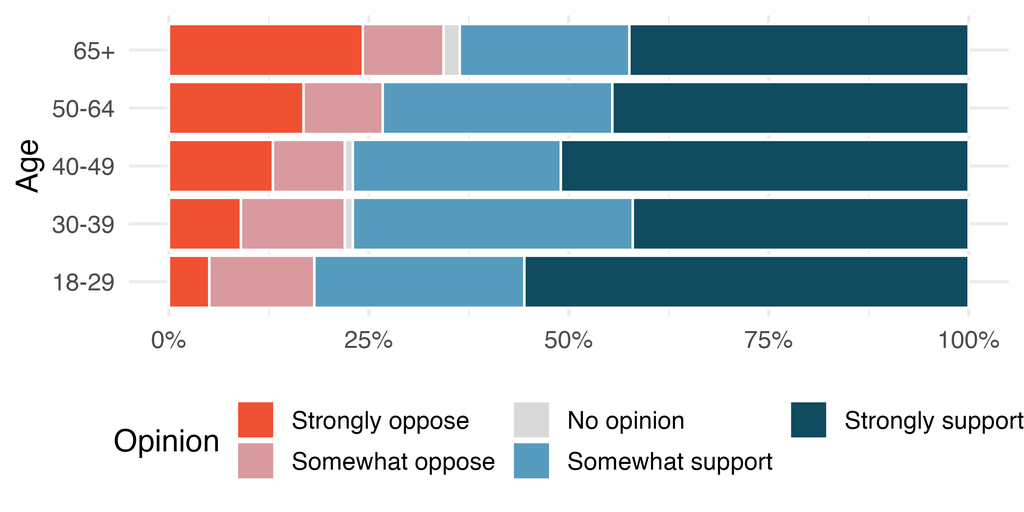

5. Based on the stacked bar plot, do views on the protests and age appear to be associated? Explain.
6. Which is the explanatory variable, and which is the response?
7. Come up with a possible confounding variable that explains this association.

# 4.6 Comparing numerical data across groups

- *Explanatory variable:* categorical
- *Response variable:* numeric

## Example: teaching evaluations

```r
glimpse(evals)
```

```
Rows: 463
Columns: 23
$ course_id     <int> 1, 2, 3, 4, 5, 6, 7, 8, 9, 10, 11, 12, 13, 14, 15, 16, 17, 18, 19, 20, 21, 2…
$ prof_id       <int> 1, 1, 1, 1, 2, 2, 2, 3, 3, 4, 4, 4, 4, 4, 4, 4, 4, 5, 5, 5, 5, 5, 5, 6, 6, 6…
$ score         <dbl> 4.7, 4.1, 3.9, 4.8, 4.6, 4.3, 2.8, 4.1, 3.4, 4.5, 3.8, 4.5, 4.6, 3.9, 3.9, 4…
$ rank          <fct> tenure track, tenure track, tenure track, tenure track, tenured, tenured, te…
$ ethnicity     <fct> minority, minority, minority, minority, not minority, not minority, not mino…
$ gender        <fct> female, female, female, female, male, male, male, male, male, female, female…
$ language      <fct> english, english, english, english, english, english, english, english, engl…
$ age           <int> 36, 36, 36, 36, 59, 59, 59, 51, 51, 40, 40, 40, 40, 40, 40, 40, 40, 31, 31, …
$ cls_perc_eval <dbl> 55.81395, 68.80000, 60.80000, 62.60163, 85.00000, 87.50000, 88.63636, 100.00…
$ cls_did_eval  <int> 24, 86, 76, 77, 17, 35, 39, 55, 111, 40, 24, 24, 17, 14, 37, 18, 15, 42, 40,…
$ cls_students  <int> 43, 125, 125, 123, 20, 40, 44, 55, 195, 46, 27, 25, 20, 25, 42, 20, 18, 48, …
$ cls_level     <fct> upper, upper, upper, upper, upper, upper, upper, upper, upper, upper, upper,…
$ cls_profs     <fct> single, single, single, single, multiple, multiple, multiple, single, single…
$ cls_credits   <fct> multi credit, multi credit, multi credit, multi credit, multi credit, multi …
$ bty_f1lower   <int> 5, 5, 5, 5, 4, 4, 4, 5, 5, 2, 2, 2, 2, 2, 2, 2, 2, 7, 7, 7, 7, 7, 7, 6, 6, 6…
$ bty_f1upper   <int> 7, 7, 7, 7, 4, 4, 4, 2, 2, 5, 5, 5, 5, 5, 5, 5, 5, 9, 9, 9, 9, 9, 9, 6, 6, 6…
$ bty_f2upper   <int> 6, 6, 6, 6, 2, 2, 2, 5, 5, 4, 4, 4, 4, 4, 4, 4, 4, 9, 9, 9, 9, 9, 9, 5, 5, 5…
$ bty_m1lower   <int> 2, 2, 2, 2, 2, 2, 2, 2, 2, 3, 3, 3, 3, 3, 3, 3, 3, 7, 7, 7, 7, 7, 7, 5, 5, 5…
$ bty_m1upper   <int> 4, 4, 4, 4, 3, 3, 3, 3, 3, 3, 3, 3, 3, 3, 3, 3, 3, 6, 6, 6, 6, 6, 6, 5, 5, 5…
$ bty_m2upper   <int> 6, 6, 6, 6, 3, 3, 3, 3, 3, 2, 2, 2, 2, 2, 2, 2, 2, 6, 6, 6, 6, 6, 6, 6, 6, 6…
$ bty_avg       <dbl> 5.000, 5.000, 5.000, 5.000, 3.000, 3.000, 3.000, 3.333, 3.333, 3.167, 3.167,…
$ pic_outfit    <fct> not formal, not formal, not formal, not formal, not formal, not formal, not …
$ pic_color     <fct> color, color, color, color, color, color, color, color, color, color, color,…
```

## Group by gender and summarize

Do men get higher teaching evaluations than women?

```r
evals %>%
  group_by(gender) %>%
  summarize(ave_eval = mean(score))
```

```
# A tibble: 2 × 2
  gender ave_eval
  <fct>     <dbl>
1 female     4.09
2 male       4.23
```

## Side-by-side Boxplots

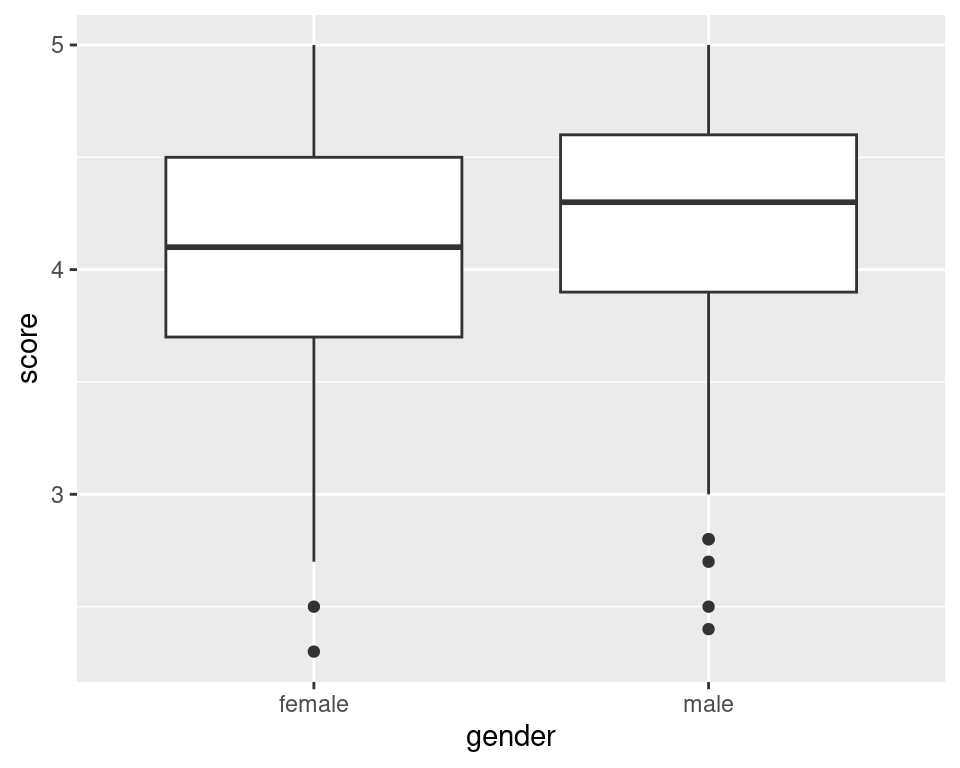

```r
evals %>%
  ggplot(aes(x = gender, y = score)) +
  geom_boxplot()
```

## Side-by-side Boxplots (horizontal)

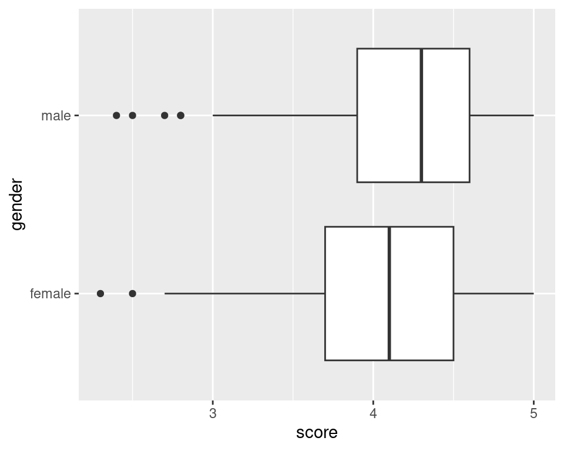

```r
evals %>%
  ggplot(aes(x = score, y = gender)) +
  geom_boxplot()
```

## Histograms

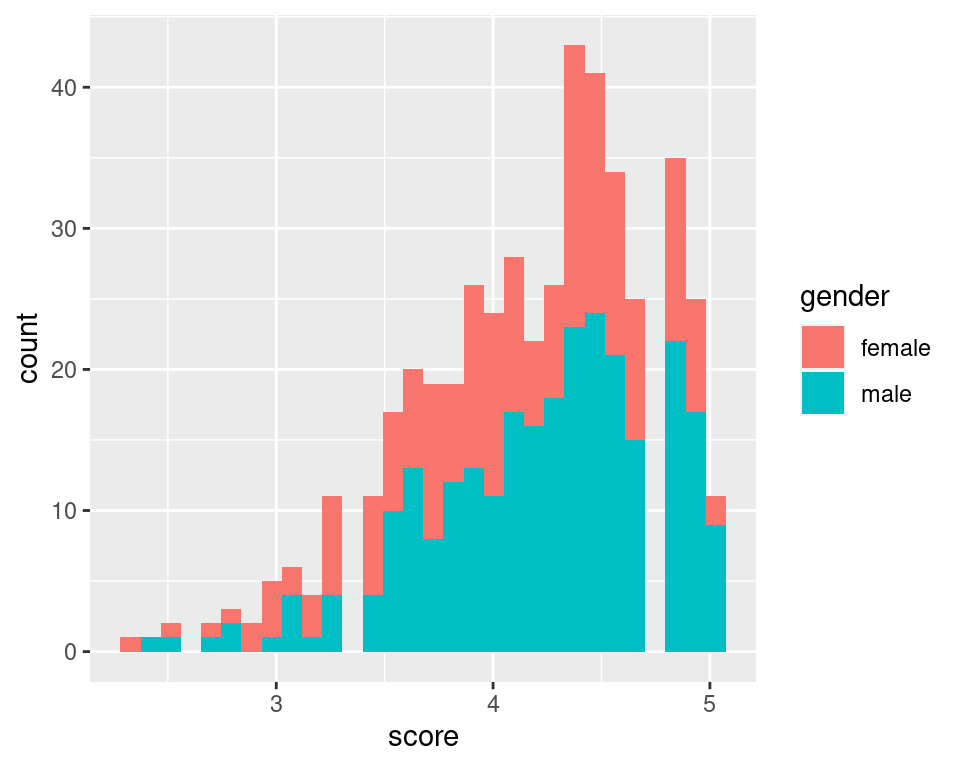

```r
evals %>%
  ggplot(aes(x = score, fill = gender)) +
  geom_histogram()
```

## Dodged Histograms

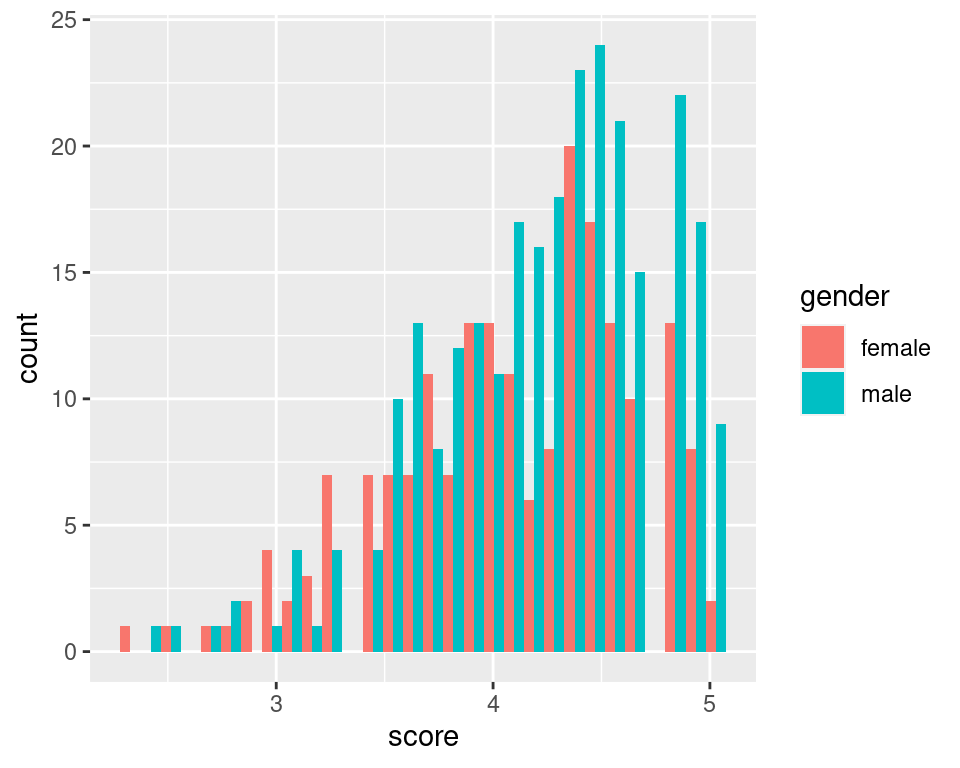

```r
evals %>%
  ggplot(aes(x = score, fill = gender)) +
  geom_histogram(position = "dodge")
```

## Density Plots

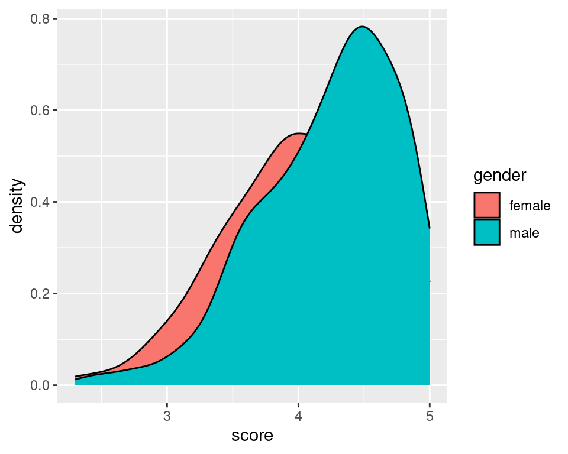

```r
evals %>%
  ggplot(aes(x = score, fill = gender)) +
  geom_density()
```

## Density Plots

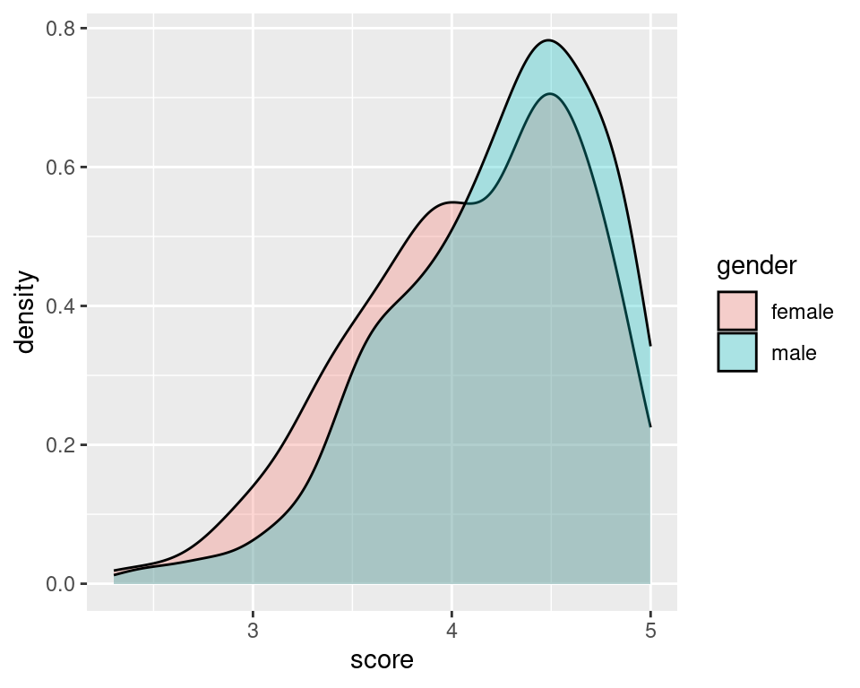

```r
evals %>%
  ggplot(aes(x = score, fill = gender)) +
  geom_density(alpha = 0.3)
```

## Ridge Plots

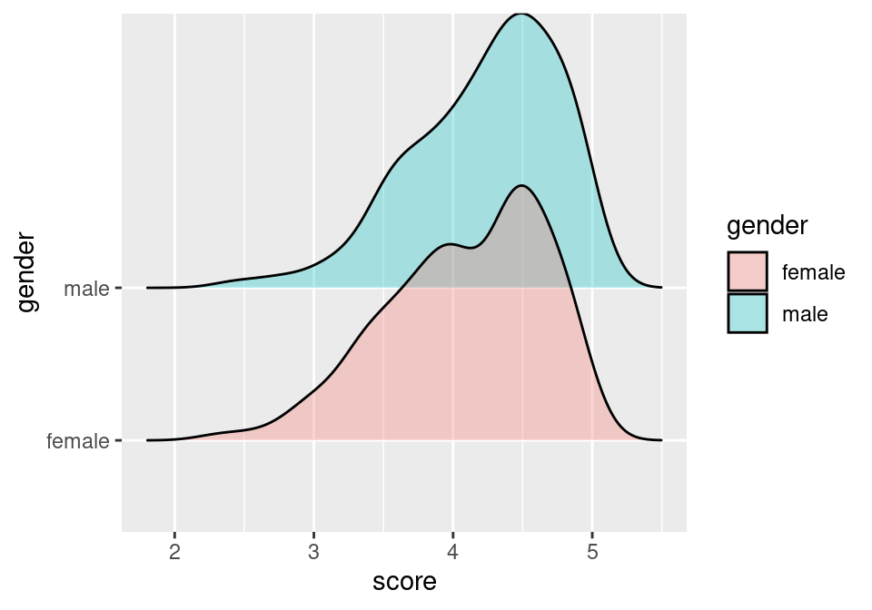

```r
library(ggridges)
evals %>%
  ggplot(aes(x = score, y = gender, fill = gender)) +
  geom_density_ridges(alpha = 0.3)
```